# Setting up R and RStudio

Milica Cudina

2020-08-29

# About R

- R is a programming language for statistics (computing and visualisation)
- For a brief history of R, go to https://en.wikipedia.org/wiki/R_(programming_language)

# Download and install R

- Go to https://cloud.r-project.org/
- Download the version of R for your operating system: Windows, Mac, or Linux
- The installation file will then get downloaded: .pkg on a Mac, or .exe on Windows, people with Linux know what they’re doing
- Follow the instructions for installation
- **There is no need to run R** (you’ll know why in a jiffy)

# About RStudio

- RStudio is an **IDE (Integrated Development Environment) for R**
- For more about RStudio, go to: https://en.wikipedia.org/wiki/RStudio

# Download and install RStudio

- Go to: https://rstudio.com/products/rstudio/download/
- Scroll down, there will be multiple versions offered
- You want **“RStudio desktop - Free”**
- Click to download
- Install following instructions
- **Now we are ready to run RStudio**

# If you run RStudio, you should see this

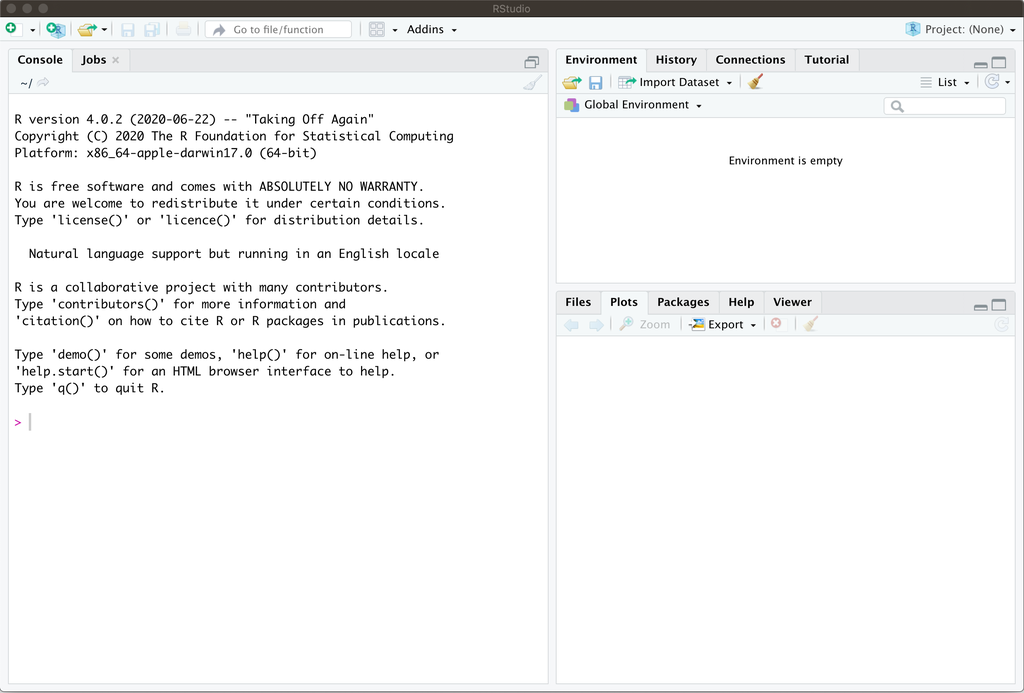

# Two adjustments

- **Open** the options window: *Cmd+,* (this means press Command and comma simultaneously) on a Mac or go to *Tools* and then all the way down to *Global Options*
- **Uncheck** “Restore .RData into workspace on startup”
- **Set** “Save workspace to .RData on exit” to “Never”

# Additional adjustments?

- If you want to export .pdf files for your assignment submissions, you will need to **install some R packages**
- To do this, you need to run up to three lines in your console (the part on the left you see when you first open RStudio)
- **Do not do this now; do it when you have a few minutes to wait for the installation to finish**

# Additional adjustments (cont’d)?

- The first line is:  
  install.packages( “tidyverse”)
- Then, remember if you have LaTeX already installed on your computer
- If you do, you’re done
- If you don’t, then run:  
  install.packages(“tinytex”)
- Then, you run:  
  tinytex::install_tinytex()

# HELP!

- Google is your best friend!
- Within the console you can type:  
  help(“command”)  
  or  
  ?command